# Problem Set 5

Due date: 23 October

Please upload your completed assignment to the ELMs course site (under the assignments menu) and to your class Github repository. You need to upload both your Quarto document (with R code, as needed) and its rendered output (either as a PDF or HTML file).

**Total points: 25**

**Note**

Please include your work. I can give you points if you are on the right track. I can’t if I can’t see what you are doing.

```r
library(scales)
library(tidyverse)
```

## Question 1

*Total points: 6*

Use the data in the table below to answer the following questions.

Voting by Age in 2000

| Age group | Non-voters | Voters | Total |
| --- | --- | --- | --- |
| 18-24 | 70 | 50 | 120 |
| 25-30 | 40 | 50 | 90 |
| 31 and up | 220 | 570 | 790 |
| TOTAL | 330 | 670 | 1000 |

### Part A

*Points: 2*

**Note**

0/2

**What is the probability of being 25-30 or a non-voter?**

**Note**

$$Pr(25\ to\ 30\ OR\ NV) = Pr(25\ to\ 30) + Pr(NV) - Pr(25\ to\ 30\ \&\ NV)$$

$$Pr(25\ to\ 30) = \frac{90}{1000} = 0.09$$

$$Pr(NV) = \frac{330}{1000} = 0.33$$

$$Pr(25\ to\ 30\ \&\ NV) = \frac{40}{1000} = 0.04$$

Therefore:

$$Pr(25\ to\ 30\ OR\ NV) = 0.09 + 0.33 - 0.04 = 0.38$$

### Part B

*Points: 4*

**Note**

0/4

**Assuming a normal distribution, report the 95% confidence intervals for the percentage of 18-to-24-year-olds who did not vote, and then the percentage of 25-to-30-year-olds who did not vote.**

**Tip**

The probability that an individual is 18-to-24 and a non-voter is not conditional. Therefore, you look at the proportion of the whole population who meet those criteria.

$$\hat{p} = Pr(18\ to\ 24 \& NV) = \frac{70}{1000} = 0.07$$

And:

$$n = 1000$$

Therefore:

$$SE(\hat{p}) = \sqrt{\frac{0.07 * 0.93}{1000}} = 0.008068457$$

The 95% confidence interval can be found:

$$\hat{p} \pm 1.96*SE(\hat{p})$$

Therefore, the 95% confidence interval for the percentage of 18-to-24-year-olds who did not vote is 5.42% to 8.58%.

Using the same method, the 95% confidence intervals for the percentage of 25-to-30-year-olds who did not vote is 2.79% to 5.21%.

## Question 2

*Total points:* *7*

**Assume that the standard deviation for the population distribution of a state in which you want to conduct a poll is 200.**

### Part A

*Points: 3*

**Note**

3/3

**Calculate the spread of the sampling distribution for each of the following sample sizes: 1, 4, 25, 100, 250, 1000, 5,000, and 10,000.**

The spread of the sampling distribution for a sample size of 1 is 200.

The spread of the sampling distribution for a sample size of 4 is 100.

The spread of the sampling distribution for a sample size of 25 is 40.

The spread of the sampling distribution for a sample size of 100 is 20.

The spread of the sampling distribution for a sample size of 250 is 12.64911064 or 12.65.

The spread of the sampling distribution for sample size of 1000 is 6.32455532 or 6.32.

The spread of the sampling distribution for sample size of 5,000 is 2.828427125 or 2.83.

The spread of the sampling distribution for sample size of 10,000 is 2.

### Part B

*Points: 1*

**Note**

1/1

**Describe specifically how the variability of the sampling distribution changes as the sample size varies. Considering the expense of running a poll, which sample size do you think is most optimal if conducting the poll?**

As the sample size increases, the variability of the sampling distribution decreases. With smaller increases of a smaller sample size, the decrease in spread and variability is more drastic (ex: the large decrease of spread given the sample size increase from 4 to 100). Yet, when the sample size increases to the thousands, the decrease in spread and variability per increase in sample size is less drastic (ex: the small decrease in the spread given the increase in sample size from 5,000 to 10,000).

Considering the expense of running a poll, I think a sample size of 1,000 would be the most optimal.

### Part C

*Points: 3*

**Note**

3/3

**Display your results graphically (using R) with the sample size on the x-axis and the standard error (of the sampling distribution) on the y-axis.**

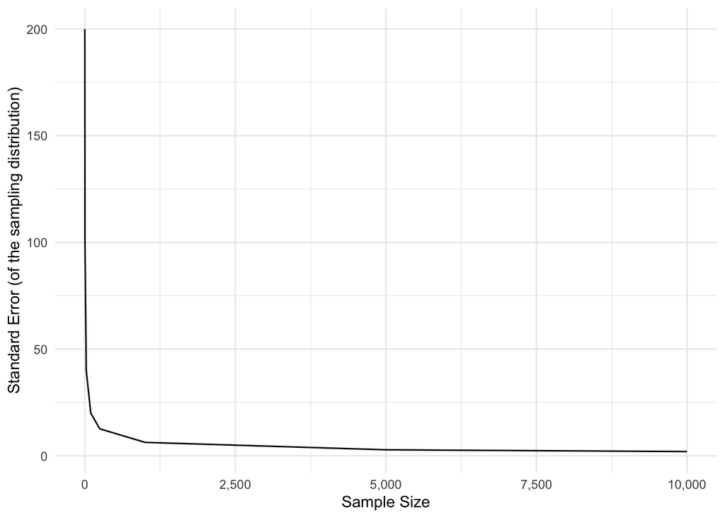

```r
spread <- c(200, 100, 40, 20, 12.65, 6.32, 2.83, 2)
sample_size <- c(1, 4, 25, 100, 250, 1000, 5000, 10000)
question_2 <- data.frame(sample_size, spread)
ggplot(question_2, aes(x = sample_size, y = spread)) +
    geom_line() +
    theme_minimal() +
    labs(x = "Sample Size",
         y = "Standard Error (of the sampling distribution)") +
    scale_x_continuous(labels = scales::label_comma())
```

## Question 3

*Points: 4*

**Note**

0/4

**Suppose you conduct a survey (to generate a sample mean of interest) and find that it has a margin of error of 4.5 with a sample size of 900 using a 95% confidence interval. What would the margin of error be for a 90% confidence interval?**

**Note**

$$ME_{95} = 4.5 = 1.96*\frac{SE}{\sqrt{n}} = 1.96*\frac{SE}{\sqrt{900}}$$

$$SE = 68.87755$$

Therefore, the margin of error for a 90% confidence interval is:

$$ME = 1.64*\frac{68.87755}{\sqrt{900}} = 3.765306$$

## Question 4

*Points: 4*

**Note**

4/4

**Assume that, in State A, the mean income in the population is $20,000 with a standard deviation of $2,000. If you took an SRS of 900 individuals from that population, what is the probability that you would get a sample mean income of $20,200 or greater? What would be the probability if the sample size was only 25?**

**Note**

Assume a normal distribution for both questions.

**Sample Size 900**

Z-score = 3

1 - .9987 = 0.0013

If you took an SRS of 900 individuals from that population, the probability that you would get a sample mean income of $20,200 or greater is 0.0013 or 0.13%.

**Sample Size 25**

Z-score: 0.5

1 - .6915 = 0.3085

If you took an SRS of 25 individuals from that population, the probability that you would get a sample mean income of $20,200 or greater is 0.3085 or 30.85%.

## Question 5

*Points: 4*

**Note**

3/4

**Assume that a coin is fair. If I flip a coin 500 times, what is a 95% confidence interval for the range of the count of heads that I will get? What if I flip the coin 5,000 times? What about 50,000 times?**

**Note**